# Machine Learning: AllLife Bank Personal Loan Campaign

## Problem Statement

### Context

AllLife Bank is a US bank that has a growing customer base. The majority of these customers are liability customers (depositors) with varying sizes of deposits. The number of customers who are also borrowers (asset customers) is quite small, and the bank is interested in expanding this base rapidly to bring in more loan business and in the process, earn more through the interest on loans. In particular, the management wants to explore ways of converting its liability customers to personal loan customers (while retaining them as depositors).

A campaign that the bank ran last year for liability customers showed a healthy conversion rate of over 9% success. This has encouraged the retail marketing department to devise campaigns with better target marketing to increase the success ratio.

You as a Data scientist at AllLife bank have to build a model that will help the marketing department to identify the potential customers who have a higher probability of purchasing the loan.

### Objective

To predict whether a liability customer will buy personal loans, to understand which customer attributes are most significant in driving purchases, and identify which segment of customers to target more.

### Data Dictionary

- `ID`: Customer ID
- `Age`: Customer’s age in completed years
- `Experience`: #years of professional experience
- `Income`: Annual income of the customer (in thousand dollars)
- `ZIP Code`: Home Address ZIP code.
- `Family`: the Family size of the customer
- `CCAvg`: Average spending on credit cards per month (in thousand dollars)
- `Education`: Education Level. 1: Undergrad; 2: Graduate;3: Advanced/Professional
- `Mortgage`: Value of house mortgage if any. (in thousand dollars)
- `Personal_Loan`: Did this customer accept the personal loan offered in the last campaign? (0: No, 1: Yes)
- `Securities_Account`: Does the customer have securities account with the bank? (0: No, 1: Yes)
- `CD_Account`: Does the customer have a certificate of deposit (CD) account with the bank? (0: No, 1: Yes)
- `Online`: Do customers use internet banking facilities? (0: No, 1: Yes)
- `CreditCard`: Does the customer use a credit card issued by any other Bank (excluding All life Bank)? (0: No, 1: Yes)

## Importing necessary libraries

```python
# Installing the libraries with the specified version.
#!pip install numpy==1.25.2 pandas==1.5.3 matplotlib==3.7.1 seaborn==0.13.1 scikit-learn==1.2.2 sklearn-pandas==2.2.0 -q --user
import pandas as pd
import numpy as np
import matplotlib.pyplot as plt
import seaborn as sns
# Removes the limit for the number of displayed columns
pd.set_option("display.max_columns", None)
# Sets the limit for the number of displayed rows
pd.set_option("display.max_rows", 200)
# setting the precision of floating numbers to 5 decimal points
pd.set_option("display.float_format", lambda x: "%.5f" % x)

# To build model for prediction
from sklearn.tree import DecisionTreeClassifier
from sklearn import tree

# To tune different models
from sklearn.model_selection import GridSearchCV

# To get diferent metric scores
from sklearn.metrics import (
    f1_score,
    accuracy_score,
    recall_score,
    precision_score,
    ConfusionMatrixDisplay,
    make_scorer,
    confusion_matrix
)

# To ignore unnecessary warnings
import warnings
warnings.filterwarnings("ignore")
# to run in google colab uncomment the following lines
#from google.colab import drive
#drive.mount('/content/drive')
```

**Note**: *After running the above cell, kindly restart the notebook kernel and run all cells sequentially from the start again.*

## Loading the dataset

```python
#df = pd.read_csv('/content/drive/MyDrive/Colab Notebooks/Project 2-Loan campaign/Loan_Modelling.csv')
df = pd.read_csv('C:\github_ep\AI-ML-Projects\Project 2-Loan campaign\Loan_Modelling.csv')
df
```

|  | ID | Age | Experience | Income | ZIPCode | Family | CCAvg | Education | Mortgage | Personal_Loan | Securities_Account | CD_Account | Online | CreditCard |
| --- | --- | --- | --- | --- | --- | --- | --- | --- | --- | --- | --- | --- | --- | --- |
| 0 | 1 | 25 | 1 | 49 | 91107 | 4 | 1.60000 | 1 | 0 | 0 | 1 | 0 | 0 | 0 |
| 1 | 2 | 45 | 19 | 34 | 90089 | 3 | 1.50000 | 1 | 0 | 0 | 1 | 0 | 0 | 0 |
| 2 | 3 | 39 | 15 | 11 | 94720 | 1 | 1.00000 | 1 | 0 | 0 | 0 | 0 | 0 | 0 |
| 3 | 4 | 35 | 9 | 100 | 94112 | 1 | 2.70000 | 2 | 0 | 0 | 0 | 0 | 0 | 0 |
| 4 | 5 | 35 | 8 | 45 | 91330 | 4 | 1.00000 | 2 | 0 | 0 | 0 | 0 | 0 | 1 |
| ... | ... | ... | ... | ... | ... | ... | ... | ... | ... | ... | ... | ... | ... | ... |
| 4995 | 4996 | 29 | 3 | 40 | 92697 | 1 | 1.90000 | 3 | 0 | 0 | 0 | 0 | 1 | 0 |
| 4996 | 4997 | 30 | 4 | 15 | 92037 | 4 | 0.40000 | 1 | 85 | 0 | 0 | 0 | 1 | 0 |
| 4997 | 4998 | 63 | 39 | 24 | 93023 | 2 | 0.30000 | 3 | 0 | 0 | 0 | 0 | 0 | 0 |
| 4998 | 4999 | 65 | 40 | 49 | 90034 | 3 | 0.50000 | 2 | 0 | 0 | 0 | 0 | 1 | 0 |
| 4999 | 5000 | 28 | 4 | 83 | 92612 | 3 | 0.80000 | 1 | 0 | 0 | 0 | 0 | 1 | 1 |

5000 rows × 14 columns

### Observations:

- 14 columns are present and all are numeric columns
- 5000 rows are present
- ID column has unique values
- 5 columns are binary columns. They are Personal_Loan, Securities_Account, CD_Account, Online, CreditCard.

## Data Overview

- Observations
- Sanity checks

```python
df.shape
```

```
(5000, 14)
```

### There are 5000 rows and 14 columns in the dataset

```python
df.info()
```

```
<class 'pandas.core.frame.DataFrame'>
RangeIndex: 5000 entries, 0 to 4999
Data columns (total 14 columns):
 #   Column              Non-Null Count  Dtype
---  ------              --------------  -----
 0   ID                  5000 non-null   int64
 1   Age                 5000 non-null   int64
 2   Experience          5000 non-null   int64
 3   Income              5000 non-null   int64
 4   ZIPCode             5000 non-null   int64
 5   Family              5000 non-null   int64
 6   CCAvg               5000 non-null   float64
 7   Education           5000 non-null   int64
 8   Mortgage            5000 non-null   int64
 9   Personal_Loan       5000 non-null   int64
 10  Securities_Account  5000 non-null   int64
 11  CD_Account          5000 non-null   int64
 12  Online              5000 non-null   int64
 13  CreditCard          5000 non-null   int64
dtypes: float64(1), int64(13)
memory usage: 547.0 KB
```

### From the df.info there are no nulls and all columns are numeric values

### Checking for unique values

```python
df.nunique()
```

```
ID                    5000
Age                     45
Experience              47
Income                 162
ZIPCode                467
Family                   4
CCAvg                  108
Education                3
Mortgage               347
Personal_Loan            2
Securities_Account       2
CD_Account               2
Online                   2
CreditCard               2
dtype: int64
```

### ID column has all unique values

### Checking for missing values

```python
df.isnull().sum()
```

```
ID                    0
Age                   0
Experience            0
Income                0
ZIPCode               0
Family                0
CCAvg                 0
Education             0
Mortgage              0
Personal_Loan         0
Securities_Account    0
CD_Account            0
Online                0
CreditCard            0
dtype: int64
```

### Checking for duplicate values

```python
df.duplicated().sum()
```

```
0
```

### Dropping the column with all values are unique

```python
df['ID'].nunique()
```

```
5000
```

```python
df.drop('ID', axis=1, inplace=True)
```

### Data Summary Statistics and Analysis

```python
df.describe().T
```

|  | count | mean | std | min | 25% | 50% | 75% | max |
| --- | --- | --- | --- | --- | --- | --- | --- | --- |
| Age | 5000.00000 | 45.33840 | 11.46317 | 23.00000 | 35.00000 | 45.00000 | 55.00000 | 67.00000 |
| Experience | 5000.00000 | 20.10460 | 11.46795 | -3.00000 | 10.00000 | 20.00000 | 30.00000 | 43.00000 |
| Income | 5000.00000 | 73.77420 | 46.03373 | 8.00000 | 39.00000 | 64.00000 | 98.00000 | 224.00000 |
| ZIPCode | 5000.00000 | 93169.25700 | 1759.45509 | 90005.00000 | 91911.00000 | 93437.00000 | 94608.00000 | 96651.00000 |
| Family | 5000.00000 | 2.39640 | 1.14766 | 1.00000 | 1.00000 | 2.00000 | 3.00000 | 4.00000 |
| CCAvg | 5000.00000 | 1.93794 | 1.74766 | 0.00000 | 0.70000 | 1.50000 | 2.50000 | 10.00000 |
| Education | 5000.00000 | 1.88100 | 0.83987 | 1.00000 | 1.00000 | 2.00000 | 3.00000 | 3.00000 |
| Mortgage | 5000.00000 | 56.49880 | 101.71380 | 0.00000 | 0.00000 | 0.00000 | 101.00000 | 635.00000 |
| Personal_Loan | 5000.00000 | 0.09600 | 0.29462 | 0.00000 | 0.00000 | 0.00000 | 0.00000 | 1.00000 |
| Securities_Account | 5000.00000 | 0.10440 | 0.30581 | 0.00000 | 0.00000 | 0.00000 | 0.00000 | 1.00000 |
| CD_Account | 5000.00000 | 0.06040 | 0.23825 | 0.00000 | 0.00000 | 0.00000 | 0.00000 | 1.00000 |
| Online | 5000.00000 | 0.59680 | 0.49059 | 0.00000 | 0.00000 | 1.00000 | 1.00000 | 1.00000 |
| CreditCard | 5000.00000 | 0.29400 | 0.45564 | 0.00000 | 0.00000 | 0.00000 | 1.00000 | 1.00000 |

- Age ranges from 23 to 67 with a mean of 45
- Experience ranges from -3 to 43.
- Income ranges from 8K to 224K with a mean of 75K and median of 64K and right skewed.
- Zipcode is a 5 digit code and there are 467 unique values
- Family size goes from 1 to 4
- Average CC spending/month is 2000 dollars, with a max of 10K
- Mortgage is right skewed with a median of 0 and mean of 56K and amount ranges from 0 to 635K ( with almost 70% of customers dont have mortgage)
- Personal-Loan: Almost 90% didnt accept the personal loan in the last campaign
- Securities Account: Almost 90% dont have the securities account
- Online banking: 40% dont use online banking
- CC other than All life bank: 70% dont possess CC other than All life bank.

```python
df[df['Mortgage'] == 0].count()
```

```
Age                   3462
Experience            3462
Income                3462
ZIPCode               3462
Family                3462
CCAvg                 3462
Education             3462
Mortgage              3462
Personal_Loan         3462
Securities_Account    3462
CD_Account            3462
Online                3462
CreditCard            3462
dtype: int64
```

```python
df[df['Experience'] < 0].count()
```

```
Age                   52
Experience            52
Income                52
ZIPCode               52
Family                52
CCAvg                 52
Education             52
Mortgage              52
Personal_Loan         52
Securities_Account    52
CD_Account            52
Online                52
CreditCard            52
dtype: int64
```

## Exploratory Data Analysis.

- EDA is an important part of any project involving data.
- It is important to investigate and understand the data better before building a model with it.
- A few questions have been mentioned below which will help you approach the analysis in the right manner and generate insights from the data.
- A thorough analysis of the data, in addition to the questions mentioned below, should be done.

**Questions**:

1. What is the distribution of mortgage attribute? Are there any noticeable patterns or outliers in the distribution?
2. How many customers have credit cards?
3. What are the attributes that have a strong correlation with the target attribute (personal loan)?
4. How does a customer's interest in purchasing a loan vary with their age?
5. How does a customer's interest in purchasing a loan vary with their education?

```python
cat_cols = ['Personal_Loan', 'Securities_Account', 'CD_Account', 'Online', 'CreditCard']
num_cols = ['Age', 'Experience', 'Income', 'Family', 'CCAvg', 'Education', 'Mortgage']
```

### 1. What is the distribution of mortgage attribute? Are there any noticeable patterns or outliers in the distribution?

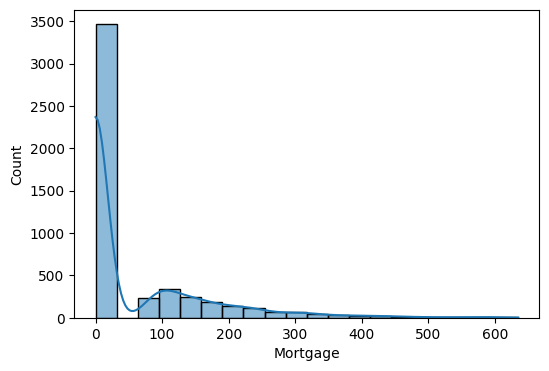

```python
plt.figure(figsize=(6, 4))
sns.histplot(data=df, x='Mortgage', bins= 20, kde=True)
plt.show()
```

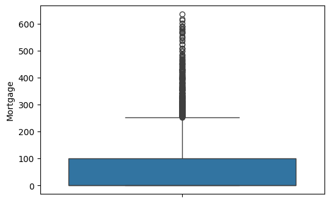

```python
plt.figure(figsize=(6, 4))
sns.boxplot(data=df, y='Mortgage')
plt.show()
```

### Response:

- From the above plots and summary stats it is evident that distribution of Mortgage is right skewed, peaked at 0 with 70% of customers dont have mortagage , and the remaining are mostly distributed between 75K to 250K and outliers are lieing between 250 to 635K. The median is 0 and the mean is 56K and the box plot shows the median line at 0, IQR with 100K and the outliers.

### 2. How many customers have credit cards?

```python
df['CreditCard'].value_counts()
```

```
CreditCard
0    3530
1    1470
Name: count, dtype: int64
```

### Response:

- 1470 customers have credit cards.

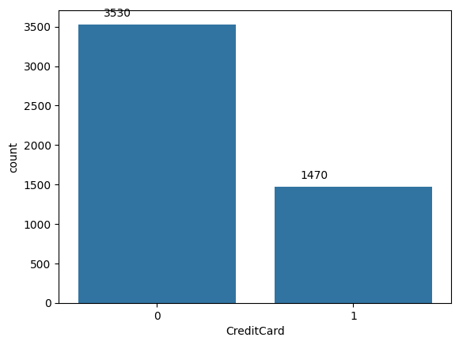

```python
ax = sns.countplot(x='CreditCard', data=df)

# Add labels on top of each bar
for p in ax.patches:
    ax.annotate(f'{int(p.get_height())}',
                (p.get_x() + p.get_width() / 4., p.get_height()),
                ha='center', va='center',
                xytext=(0, 10),
                textcoords='offset points')
```

### 3. What are the attributes that have a strong correlation with the target attribute (personal loan)?

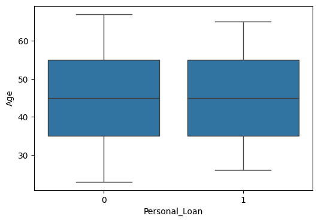

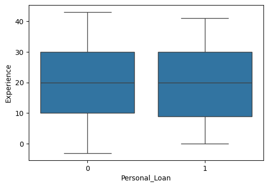

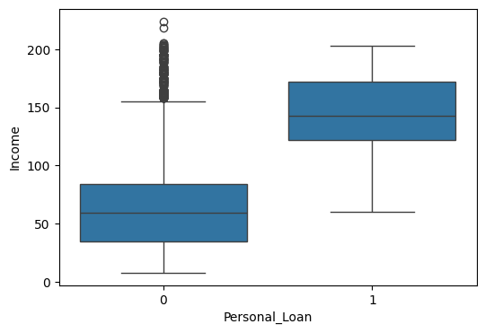

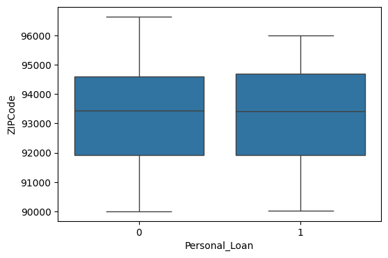

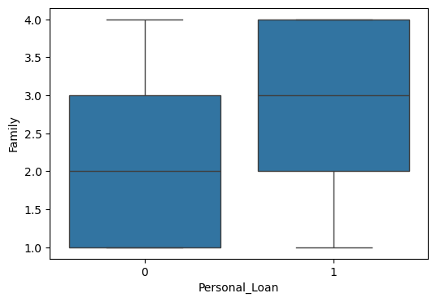

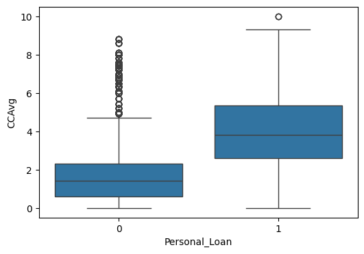

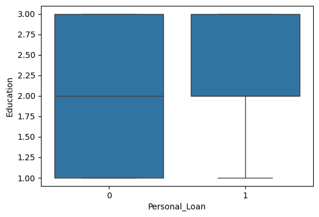

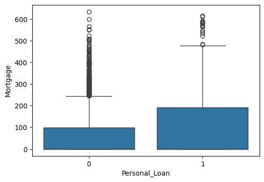

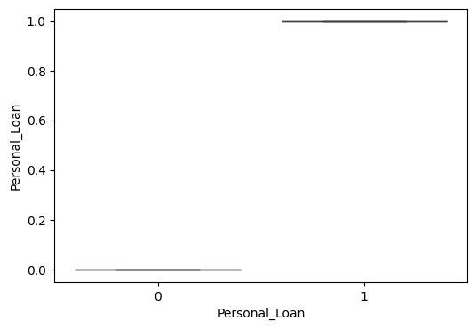

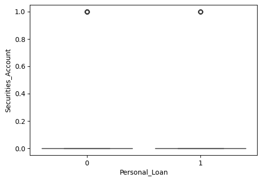

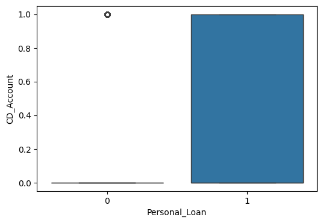

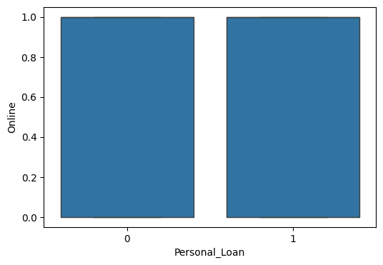

[1 more figures not shown]

```python
for col in df.columns:
  plt.figure(figsize=(6, 4))
  sns.boxplot(data=df, x='Personal_Loan', y=col)
  plt.show()
```

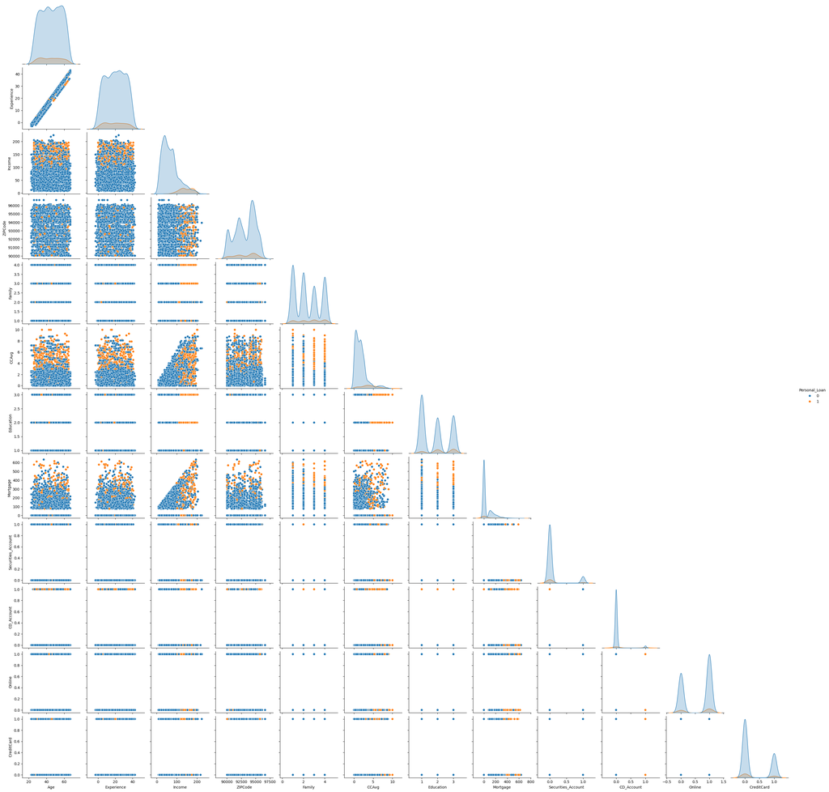

```python
sns.pairplot(df, hue='Personal_Loan', corner=True)
plt.show()
```

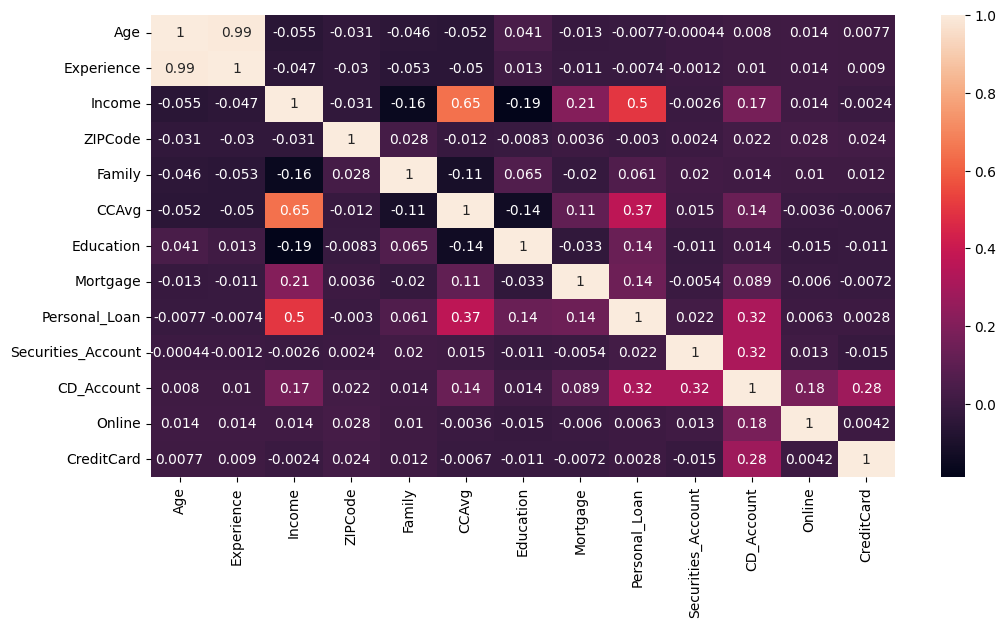

```python
plt.figure(figsize=(12, 6))
sns.heatmap(df.corr(), annot=True)
plt.show()
```

### Response:

From the above box plots, heatmap Income, CCAvg , CD_Account have stronger correlation to target variable Personal_loan.

### 4. How does a customer's interest in purchasing a loan vary with their age?

```python
df[df['Personal_Loan'] == 1].Age.describe()
```

```
count   480.00000
mean     45.06667
std      11.59096
min      26.00000
25%      35.00000
50%      45.00000
75%      55.00000
max      65.00000
Name: Age, dtype: float64
```

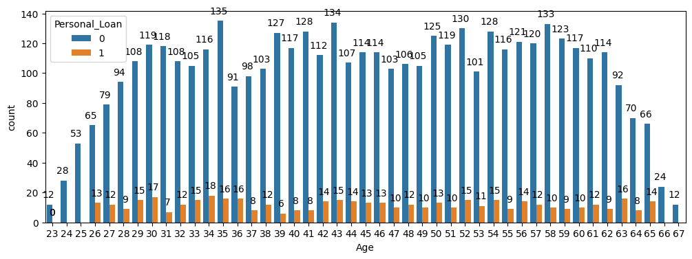

```python
plt.figure(figsize=(12, 4))
ax = sns.countplot(data=df, x='Age', hue='Personal_Loan')
# Add labels on top of each bar
for p in ax.patches:
    ax.annotate(f'{int(p.get_height())}',
                (p.get_x() + p.get_width() / 4., p.get_height()),
                ha='center', va='center',
                xytext=(0, 10),
                textcoords='offset points')
plt.show()
```

### 5. How does a customer's interest in purchasing a loan vary with their education?

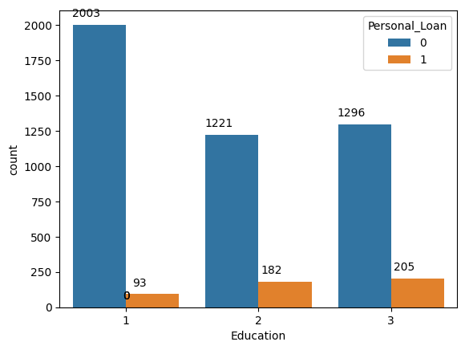

```python
ax = sns.countplot(data=df, x='Education', hue='Personal_Loan')
# Add labels on top of each bar
for p in ax.patches:
    ax.annotate(f'{int(p.get_height())}',
                (p.get_x() + p.get_width() / 4., p.get_height()),
                ha='center', va='center',
                xytext=(0, 10),
                textcoords='offset points')
plt.show()
```

### Response:

Education has a positive correlation to the target variable personal loan. Only 10% of customers have interest to purchase loans and out of which customers with higher level of education have more interest to purchase personal loans.

## Data Preprocessing

- Missing value treatment
- Feature engineering (if needed)
- Outlier detection and treatment (if needed)
- Preparing data for modeling
- Any other preprocessing steps (if needed)

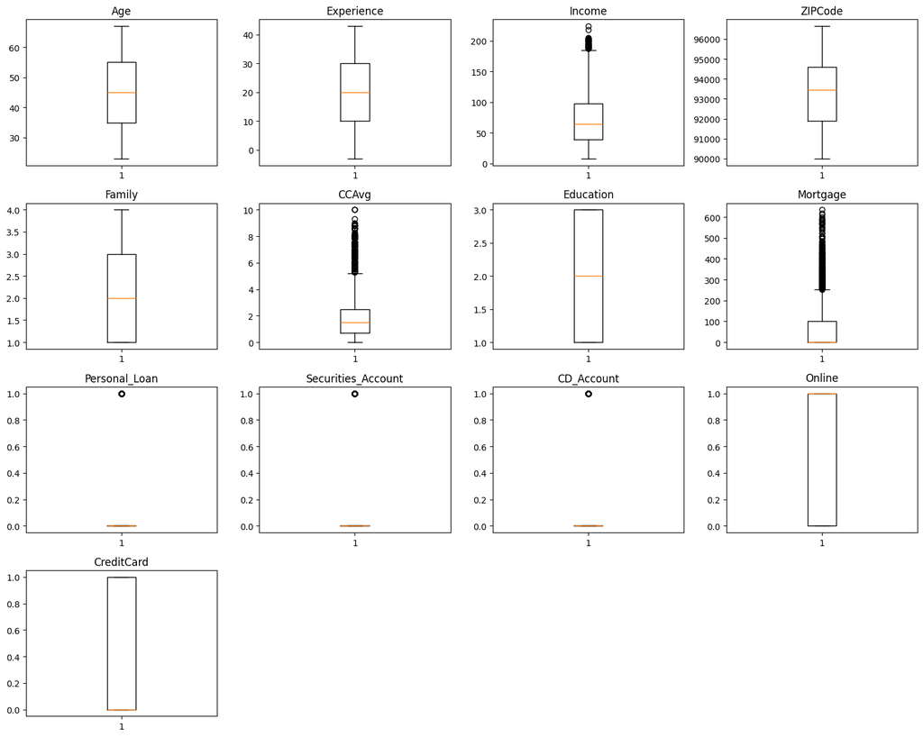

```python
# outlier detection using boxplot
numeric_columns = df.select_dtypes(include=np.number).columns.tolist()

plt.figure(figsize=(15, 12))

for i, variable in enumerate(numeric_columns):
    plt.subplot(4, 4, i + 1)
    plt.boxplot(df[variable], whis=1.5)
    plt.tight_layout()
    plt.title(variable)

plt.show()
```

#### Observations:

- There are no missing values or duplicates.
- The unique ID column is removed from the dataset.
- There are some outliers but they have vaues and can be used as such.

### Data Preparation for Modeling

```python
from sklearn.model_selection import train_test_split
X = df.drop('Personal_Loan', axis=1)
y = df['Personal_Loan']
X_train, X_test, y_train, y_test = train_test_split(X, y, test_size=0.3, random_state=1)
```

```python
print("Shape of Training set : ", X_train.shape)
print("Shape of test set : ", X_test.shape)
print("Percentage of classes in training set:")
print(y_train.value_counts(normalize=True))
print("Percentage of classes in test set:")
print(y_test.value_counts(normalize=True))
```

```
Shape of Training set :  (3500, 12)
Shape of test set :  (1500, 12)
Percentage of classes in training set:
Personal_Loan
0   0.90543
1   0.09457
Name: proportion, dtype: float64
Percentage of classes in test set:
Personal_Loan
0   0.90067
1   0.09933
Name: proportion, dtype: float64
```

- In the train and test target column there is 90% of class 0 ie ( cutsomers without loan) and 10% of class 1 ie( customers with loan) are present.

## Model Building - Decision Tree (Default)

```python
model1 = DecisionTreeClassifier(random_state=1)
model1.fit(X_train, y_train)
```

```
DecisionTreeClassifier(random_state=1)
```

### Model Evaluation metrics and Confusion Matrix

- Predicting a customer will not loan and in reality he loans will not incur any loss for the bank ( False Negative).
- Predicting a customer will loan and in reality he does not loan will incur loss for the bank as it involves cost in campaigning. ( False Positive) How to reduce the loss?
- Our goal is to minimize the false positive case predicting the customer will loan and in reality he does not.
- To reduce the number of false positives the precision metric needs to be higher. Precision = TP / (TP + FP)

```python
# defining a function to compute different metrics to check performance of a classification model built using sklearn
def model_performance_classification_sklearn(model, predictors, target):
    """
    Function to compute different metrics to check classification model performance

    model: classifier
    predictors: independent variables
    target: dependent variable
    """

    # predicting using the independent variables
    pred = model.predict(predictors)

    acc = accuracy_score(target, pred)  # to compute Accuracy
    recall = recall_score(target, pred)  # to compute Recall
    precision = precision_score(target, pred)  # to compute Precision
    f1 = f1_score(target, pred)  # to compute F1-score

    # creating a dataframe of metrics
    df_perf = pd.DataFrame(
        {"Accuracy": acc, "Recall": recall, "Precision": precision, "F1": f1,},
        index=[0],
    )

    return df_perf
```

```python
def confusion_matrix_sklearn(model, predictors, target):
    """
    To plot the confusion_matrix with percentages

    model: classifier
    predictors: independent variables
    target: dependent variable
    """
    y_pred = model.predict(predictors)
    cm = confusion_matrix(target, y_pred)
    labels = np.asarray(
        [
            ["{0:0.0f}".format(item) + "\n{0:.2%}".format(item / cm.flatten().sum())]
            for item in cm.flatten()
        ]
    ).reshape(2, 2)
    plt.figure(figsize=(6, 4))
    sns.heatmap(cm, annot=labels, fmt="")
    plt.ylabel("True label")
    plt.xlabel("Predicted label")
```

#### Model (default decision tree) performance on train data

```python
model1_perf_metrics = model_performance_classification_sklearn(model1, X_train, y_train)
model1_perf_metrics
```

|  | Accuracy | Recall | Precision | F1 |
| --- | --- | --- | --- | --- |
| 0 | 1.00000 | 1.00000 | 1.00000 | 1.00000 |

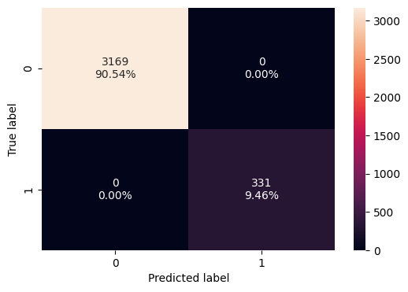

```python
confusion_matrix_sklearn(model1, X_train, y_train)
```

### Observations: The model is a overfit model with a 100% accuracy, precision, recall, F1 score on training dataset.

### Model (default decision tree) Evaluation metrics on test dataset

```python
model1_perf_metrics_test = model_performance_classification_sklearn(model1, X_test, y_test)
model1_perf_metrics_test
```

|  | Accuracy | Recall | Precision | F1 |
| --- | --- | --- | --- | --- |
| 0 | 0.98000 | 0.88591 | 0.91034 | 0.89796 |

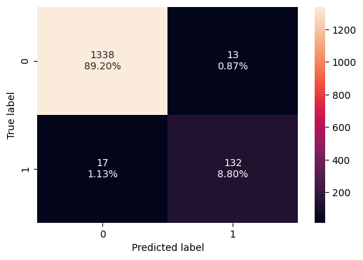

```python
confusion_matrix_sklearn(model1, X_test, y_test)
```

```python
model1.feature_importances_
feature_names = list(X_train.columns)
indices = np.argsort(model1.feature_importances_)
for idx in indices:
    print(f"{feature_names[idx]}: {model1.feature_importances_[idx]:.4f}")
```

```
ZIPCode: 0.0000
Securities_Account: 0.0000
CreditCard: 0.0000
Online: 0.0006
Mortgage: 0.0030
Experience: 0.0112
CD_Account: 0.0257
Age: 0.0357
CCAvg: 0.0444
Family: 0.1696
Income: 0.3083
Education: 0.4015
```

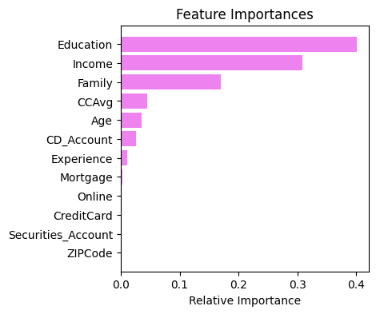

```python
plt.figure(figsize=(4,4))
plt.title("Feature Importances")
plt.barh(range(len(indices)), model1.feature_importances_[indices], color="violet", align="center")
plt.yticks(range(len(indices)), [feature_names[i] for i in indices])
plt.xlabel("Relative Importance")
plt.show()
```

### Observations from Default Decision Tree Model:

- The precision score for test dataset looks quite good which is 0.91 and the recall score is 0.88 which is also a good score. But the model is overfit on training dataset. So we need to use optimization techniques with hyper parameters to avoid overfitting.

### Model Building: Decision Tree Classifier with Class Weights

- Since our dataset contains a dominant class and a minority class the model will be biased in predicting the dominant class.
- In order to distribute the class weights evenly we can add a hyper parameter to the classifier and weights are adjusted between 2 classes and the model will pay more attention on minority class as well.

```python
model2 = DecisionTreeClassifier(random_state=1, class_weight='balanced')
model2.fit(X_train, y_train)
```

```
DecisionTreeClassifier(class_weight='balanced', random_state=1)
```

### Model evaluation metrics and confusion matrix for Decision tree classifier with weights for training data

```python
model2_perf_metrics = model_performance_classification_sklearn(model2, X_train, y_train)
model2_perf_metrics
```

|  | Accuracy | Recall | Precision | F1 |
| --- | --- | --- | --- | --- |
| 0 | 1.00000 | 1.00000 | 1.00000 | 1.00000 |

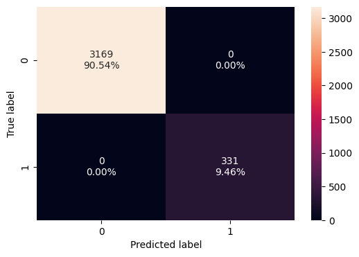

```python
confusion_matrix_sklearn(model2, X_train, y_train)
```

### Model evaluation metrics and confusion matrix for decision tree with weights for test data

```python
model2_perf_metrics_test = model_performance_classification_sklearn(model2, X_test, y_test)
model2_perf_metrics_test
```

|  | Accuracy | Recall | Precision | F1 |
| --- | --- | --- | --- | --- |
| 0 | 0.97467 | 0.85906 | 0.88276 | 0.87075 |

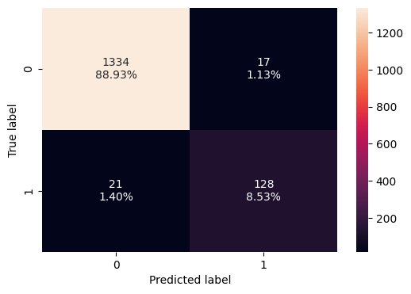

```python
confusion_matrix_sklearn(model2, X_test, y_test)
```

```python
model2.feature_importances_
feature_names = list(X_train.columns)
indices = np.argsort(model2.feature_importances_)
for idx in indices:
    print(f"{feature_names[idx]}: {model2.feature_importances_[idx]:.4f}")
```

```
CreditCard: 0.0000
Securities_Account: 0.0006
Online: 0.0010
Mortgage: 0.0051
Age: 0.0055
CD_Account: 0.0081
Experience: 0.0083
ZIPCode: 0.0137
Education: 0.0845
CCAvg: 0.0917
Family: 0.1480
Income: 0.6335
```

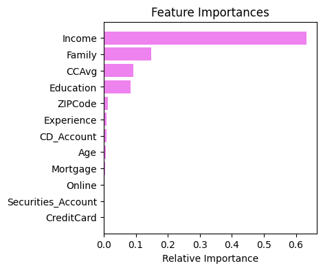

```python
plt.figure(figsize=(4,4))
plt.title("Feature Importances")
plt.barh(range(len(indices)), model2.feature_importances_[indices], color="violet", align="center")
plt.yticks(range(len(indices)), [feature_names[i] for i in indices])
plt.xlabel("Relative Importance")
plt.show()
```

** Looks like our default model is better in prediction compared to the model with class weights balanced.** But it is a overfit model and so we will use pre-pruning and post pruning techniques for optimization

### Model Building: Decision Tree with Pre-Pruning

**Using GridSearch for Hyperparameter tuning of our decision tree model**

- Grid search is a tuning technique that attempts to compute the optimum values of hyperparameters.
- Grid Search performs an exhaustive search using cross validation and choose the best hyperparameters for the model and ensures the parameters generalize well on unseen data.
- The parameters of the estimator/model used to apply these methods are optimized by cross-validated grid-search over a parameter grid.

```python
# Choose the type of classifier.
estimator = DecisionTreeClassifier(random_state=1)

# Grid of parameters to choose from
parameters = {
    "class_weight": [None, "balanced"],
    "max_depth": np.arange(2, 7, 2), # [2, 4, 6]
    "max_leaf_nodes": [50, 75, 150, 250],
    "min_samples_split": [10, 30, 50, 70],
}

# Type of scoring used to compare parameter combinations
acc_scorer = make_scorer(precision_score)

# Run the grid search
grid_obj = GridSearchCV(estimator, parameters, scoring=acc_scorer, cv=5)
grid_obj = grid_obj.fit(X_train, y_train)

# Set the clf to the best combination of parameters
estimator = grid_obj.best_estimator_

# Fit the best algorithm to the data.
estimator.fit(X_train, y_train)
```

```
DecisionTreeClassifier(max_depth=4, max_leaf_nodes=50, min_samples_split=70,
                       random_state=1)
```

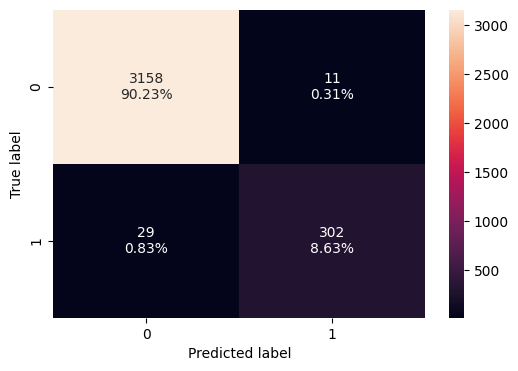

```python
confusion_matrix_sklearn(estimator, X_train, y_train)
```

```python
model3_perf_metrics = model_performance_classification_sklearn(estimator, X_train, y_train)
model3_perf_metrics
```

|  | Accuracy | Recall | Precision | F1 |
| --- | --- | --- | --- | --- |
| 0 | 0.98857 | 0.91239 | 0.96486 | 0.93789 |

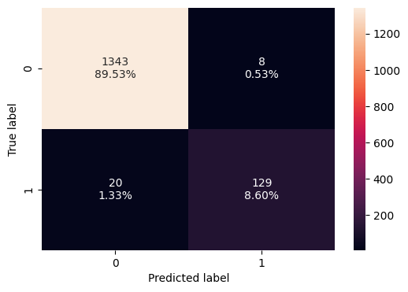

```python
confusion_matrix_sklearn(estimator, X_test, y_test)
```

```python
model3_perf_metrics_test = model_performance_classification_sklearn(estimator, X_test, y_test)
model3_perf_metrics_test
```

|  | Accuracy | Recall | Precision | F1 |
| --- | --- | --- | --- | --- |
| 0 | 0.98133 | 0.86577 | 0.94161 | 0.90210 |

### Observations:

Model outputs precision score of 0.96 on train and 0.94 on test data indicates that the model is able to generalize well on unseen data.

### Feature Importances:

- Features and Importance of features:
- score is assigned to each feature based on its relavance to the classification task

```python
feature_names = list(X_train.columns)
feature_names
importances = estimator.feature_importances_  # fetch the feature importance
indices = np.argsort(importances) # sort the importances in ascending order and return the indices
for idx in indices:
    print(f"{feature_names[idx]}: {importances[idx]:.4f}")
```

```
Age: 0.0000
Experience: 0.0000
ZIPCode: 0.0000
Mortgage: 0.0000
Securities_Account: 0.0000
Online: 0.0000
CreditCard: 0.0000
CD_Account: 0.0152
CCAvg: 0.0423
Family: 0.1603
Income: 0.3334
Education: 0.4488
```

- Visualizing the pre-pruned Decision tree

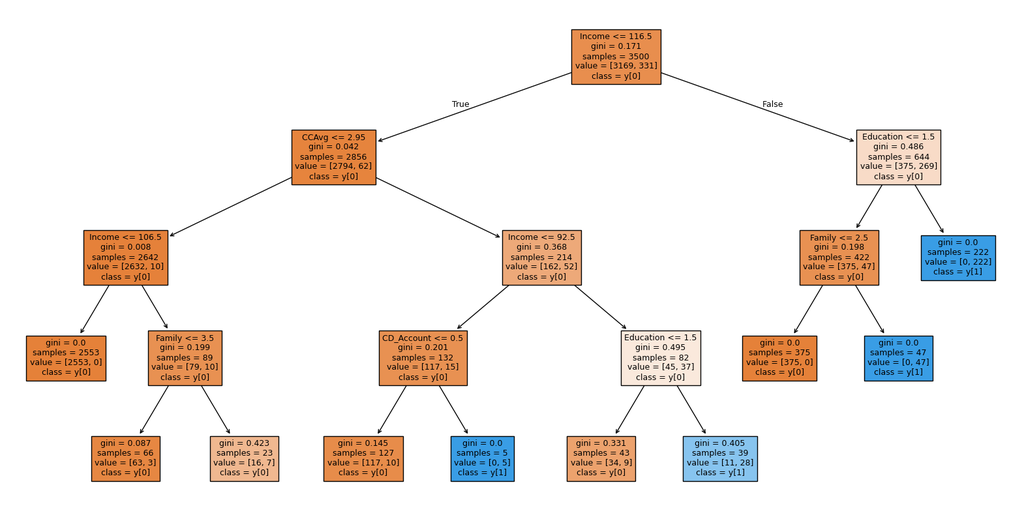

```python
plt.figure(figsize=(20, 10))
out = tree.plot_tree(
    estimator,
    feature_names=feature_names,
    filled=True,
    fontsize=9,
    node_ids=False,
    class_names=True,
)
plt.show()
```

```python
# Text report showing the rules of a decision tree -
print(tree.export_text(estimator, feature_names=feature_names, show_weights=True))
```

```
|--- Income <= 116.50
|   |--- CCAvg <= 2.95
|   |   |--- Income <= 106.50
|   |   |   |--- weights: [2553.00, 0.00] class: 0
|   |   |--- Income >  106.50
|   |   |   |--- Family <= 3.50
|   |   |   |   |--- weights: [63.00, 3.00] class: 0
|   |   |   |--- Family >  3.50
|   |   |   |   |--- weights: [16.00, 7.00] class: 0
|   |--- CCAvg >  2.95
|   |   |--- Income <= 92.50
|   |   |   |--- CD_Account <= 0.50
|   |   |   |   |--- weights: [117.00, 10.00] class: 0
|   |   |   |--- CD_Account >  0.50
|   |   |   |   |--- weights: [0.00, 5.00] class: 1
|   |   |--- Income >  92.50
|   |   |   |--- Education <= 1.50
|   |   |   |   |--- weights: [34.00, 9.00] class: 0
|   |   |   |--- Education >  1.50
|   |   |   |   |--- weights: [11.00, 28.00] class: 1
|--- Income >  116.50
|   |--- Education <= 1.50
|   |   |--- Family <= 2.50
|   |   |   |--- weights: [375.00, 0.00] class: 0
|   |   |--- Family >  2.50
|   |   |   |--- weights: [0.00, 47.00] class: 1
|   |--- Education >  1.50
|   |   |--- weights: [0.00, 222.00] class: 1
```

- Interpretation of tree:
- If the Income is above 116.5K and education is above 1.5 , then customer will buy loan more likely. (class 1)
- If the income is above 116.5K and education is below 1.5, and family size is above 2.5, then they more likely to buy loan. (class 1)
- If the income is above 116.5K and education is below 1.5, and family size is below 2.5, then they less likely to buy loan.( Class 0)

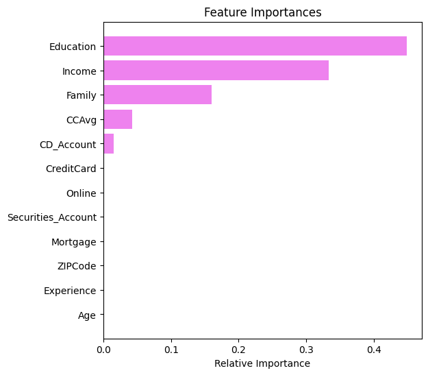

```python
plt.figure(figsize=(6, 6))
plt.title("Feature Importances")
plt.barh(range(len(indices)), importances[indices], color="violet", align="center")
plt.yticks(range(len(indices)), [feature_names[i] for i in indices])
plt.xlabel("Relative Importance")
plt.show()
```

### Model Building: Decision Tree with Post-Pruning

The `DecisionTreeClassifier` provides parameters such as `min_samples_leaf` and `max_depth` to prevent a tree from overfiting. Cost complexity pruning provides another option to control the size of a tree. In `DecisionTreeClassifier`, this pruning technique is parameterized by the cost complexity parameter, `ccp_alpha`. Greater values of `ccp_alpha` increase the number of nodes pruned. Here we only show the effect of `ccp_alpha` on regularizing the trees and how to choose a `ccp_alpha` based on validation scores.

**Total impurity of leaves vs effective alphas of pruned tree**

Minimal cost complexity pruning recursively finds the node with the "weakest link". The weakest link is characterized by an effective alpha, where the nodes with the smallest effective alpha are pruned first. To get an idea of what values of `ccp_alpha` could be appropriate, scikit-learn provides `DecisionTreeClassifier.cost_complexity_pruning_path` that returns the effective alphas and the corresponding total leaf impurities at each step of the pruning process. As alpha increases, more of the tree is pruned, which increases the total impurity of its leaves.

```python
clf = DecisionTreeClassifier(random_state=1) # {0: 0.15, 1: 0.85}
path = clf.cost_complexity_pruning_path(X_train, y_train)
ccp_alphas, impurities = abs(path.ccp_alphas), path.impurities
```

```python
path_df = pd.DataFrame(path)
path_df
```

|  | ccp_alphas | impurities |
| --- | --- | --- |
| 0 | 0.00000 | 0.00000 |
| 1 | 0.00022 | 0.00111 |
| 2 | 0.00027 | 0.00219 |
| 3 | 0.00036 | 0.00326 |
| 4 | 0.00038 | 0.00364 |
| 5 | 0.00038 | 0.00403 |
| 6 | 0.00038 | 0.00441 |
| 7 | 0.00038 | 0.00479 |
| 8 | 0.00041 | 0.00642 |
| 9 | 0.00048 | 0.00690 |
| 10 | 0.00051 | 0.00741 |
| 11 | 0.00058 | 0.00799 |
| 12 | 0.00059 | 0.00917 |
| 13 | 0.00064 | 0.01174 |
| 14 | 0.00077 | 0.01482 |
| 15 | 0.00079 | 0.01798 |
| 16 | 0.00155 | 0.01954 |
| 17 | 0.00233 | 0.02187 |
| 18 | 0.00302 | 0.02489 |
| 19 | 0.00329 | 0.02819 |
| 20 | 0.00647 | 0.03466 |
| 21 | 0.02387 | 0.05853 |
| 22 | 0.05636 | 0.17126 |

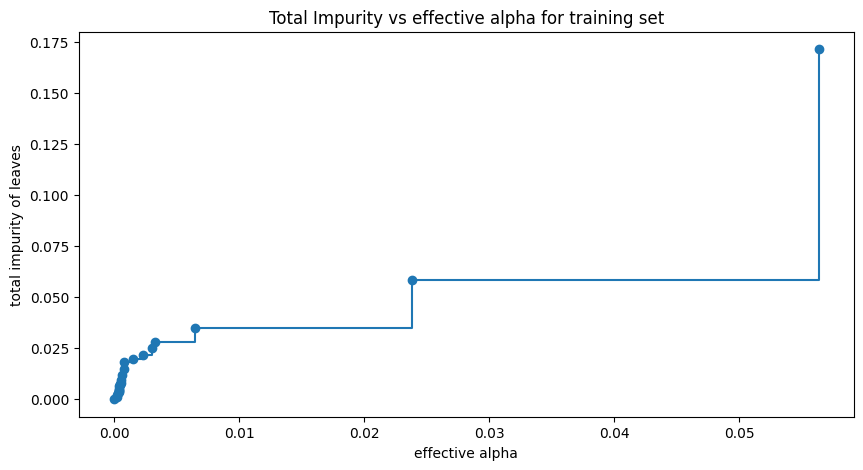

```python
fig, ax = plt.subplots(figsize=(10, 5))
ax.plot(path_df['ccp_alphas'], path_df['impurities'], marker="o", drawstyle="steps-post")
ax.set_xlabel("effective alpha")
ax.set_ylabel("total impurity of leaves")
ax.set_title("Total Impurity vs effective alpha for training set")
plt.show()
```

Next, we train a decision tree using the effective alphas. The last value in `ccp_alphas` is the alpha value that prunes the whole tree, leaving the tree, `clfs[-1]`, with one node.

```python
clfs = []
for ccp_alpha in ccp_alphas:
    clf = DecisionTreeClassifier(
        random_state=1, ccp_alpha=ccp_alpha
    )
    clf.fit(X_train, y_train)
    clfs.append(clf)
print(
    "Number of nodes in the last tree is: {} with ccp_alpha: {}".format(
        clfs[-1].tree_.node_count, ccp_alphas[-1]
    )
)
```

```
Number of nodes in the last tree is: 1 with ccp_alpha: 0.056364969335601575
```

For the remainder, we remove the last element in `clfs` and `ccp_alphas`, because it is the trivial tree with only one node. Here we show that the number of nodes and tree depth decreases as alpha increases.

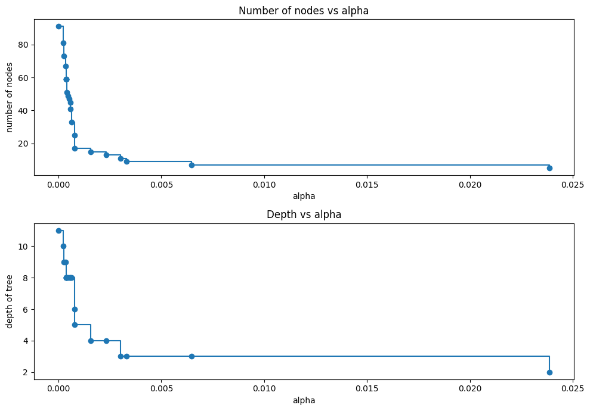

```python
clfs = clfs[:-1]
ccp_alphas = ccp_alphas[:-1]

node_counts = [clf.tree_.node_count for clf in clfs]
depth = [clf.tree_.max_depth for clf in clfs]
fig, ax = plt.subplots(2, 1, figsize=(10, 7))
ax[0].plot(ccp_alphas, node_counts, marker="o", drawstyle="steps-post")
ax[0].set_xlabel("alpha")
ax[0].set_ylabel("number of nodes")
ax[0].set_title("Number of nodes vs alpha")
ax[1].plot(ccp_alphas, depth, marker="o", drawstyle="steps-post")
ax[1].set_xlabel("alpha")
ax[1].set_ylabel("depth of tree")
ax[1].set_title("Depth vs alpha")
fig.tight_layout()
```

```python
precision_train = []
for clf in clfs:
    pred_train = clf.predict(X_train)
    values_train = precision_score(y_train, pred_train)
    precision_train.append(values_train)
```

```python
precision_test = []
for clf in clfs:
    pred_test = clf.predict(X_test)
    values_test = precision_score(y_test, pred_test)
    precision_test.append(values_test)
```

```python
train_scores = [clf.score(X_train, y_train) for clf in clfs]
test_scores = [clf.score(X_test, y_test) for clf in clfs]
```